# Proyecto 1: Series de tiempo

02/05/2022

## Tarea 3

### 1. Análisis descriptivo

Grafique los datos, describa lo que observe (varianza constante o no, descomposición clásica, tendencia, ciclos estacionales, periodicidad de los datos).

**Solución:** Comenzamos por cargar y ver los datos:

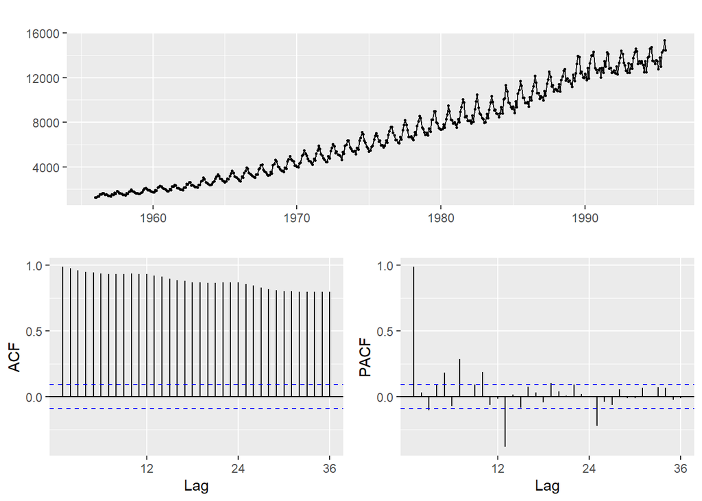

```r
ts_122 <- tsdl[[122]]
ggtsdisplay(ts_122)
```

donde observamos que la serie de tiempo tiene varianza no constante ya que a medida que pasa el tiempo la dispersión de los datos va creciendo. Además, tenemos un ciclo estacional con periocidad de 12 meses. Gracias a la gráfica ACF podemos observar que los datos están correlacionados, al parecer, dada una observación, ésta depende de la observación anterior.

Asimismo podemos observar las siguientes gráficas

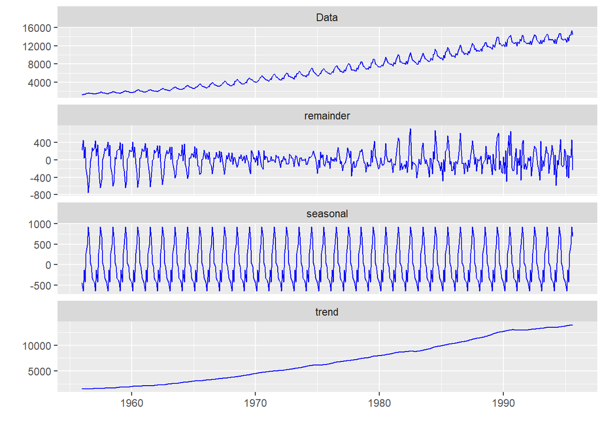

```r
autoplot(stl(ts_122, s.window = "periodic"), ts.colour = "blue")
```

de las cuales, la tendencia sostiene la misma dirección durante un amplio período de tiempo y también puede decirse que ésta es lineal.

### 2. Missing data

Suponga que las observaciones de `1993 Jan, Feb` y `1994 Mar` son datos faltantes, es decir, sustituya estas observaciones por `NA`

**Solución:**

Los valores que sustituiremos por `NA's` son los correspondientes a Enero y Febrero de 1993 y Marzo de 1994. Estos valores los asignaremos a un vector

```r
# Valores observados para estos meses:
# Jan 1993, Feb 1993, Mar 1994
valores = c(ts_122[37*12+1], ts_122[37*12+2], ts_122[38*12+3])
valores
```

```
## [1] 13287 12434 13489
```

Sustitución de los valores en `1993 Jan, 1993 Feb` y `1994 Mar` por `NA's`:

```r
# Enero 1993
ts_122[37*12+1] = NA
# Febrero 1993
ts_122[37*12+2] = NA
# Marzo 1994
ts_122[38*12+3] = NA
# Corroboramos que dichos valores tengan NA's asignados
val_na = c(ts_122[37*12+1], ts_122[37*12+2], ts_122[38*12+3])
val_na
```

```
## [1] NA NA NA
```

y procedemos a las imputaciones:

```r
# Serie de tiempo imputando por el método  de medias móviles
ST1 <- ts_122
ST1 <- na_ma(ST1)
valores1 = c(ST1[37*12+1], ST1[37*12+2], ST1[38*12+3])
valores1
```

```
## [1] 12811.95 13038.05 13023.03
```

```r
# Serie de tiempo imputando por el método  de medias móviles
# con pesos exponenciales
ST2 <- ts_122
ST2 <- na_ma(ST2, weighting = "exponential")
valores2 = c(ST2[37*12+1], ST2[37*12+2], ST2[38*12+3])
valores2
```

```
## [1] 12811.95 13038.05 13023.03
```

```r
# Serie de tiempo imputando por el método interpolación
ST3 <- ts_122
ST3 <- na_interpolation(ST3)
valores3 = c(ST3[37*12+1], ST3[37*12+2], ST3[38*12+3])
valores3
```

```
## [1] 12693 12951 12513
```

```r
# Serie de tiempo imputando por el método Kalman
ST4 <- ts_122
ST4 <- na_kalman(ST4)
valores4 = c(ST4[37*12+1], ST4[37*12+2], ST4[38*12+3])
valores4
```

```
## [1] 12902.95 12384.27 13453.89
```

Y comparamos las aproximaciones obtenidas por los distintos métodos de imputación con los valores observados:

```r
df_im <- data.frame(
 "Valores observados" = valores,
 "Método_MA" = valores1,
 "Método_MA_wt_exponencial" = valores2,
 "Método_de_interpolación" = valores3,
 "Método_de_Kalman" = valores4
)
df_im
```

```
##   Valores.observados Método_MA Método_MA_wt_exponencial Método_de_interpolación
## 1              13287  12811.95                 12811.95                   12693
## 2              12434  13038.05                 13038.05                   12951
## 3              13489  13023.03                 13023.03                   12513
##   Método_de_Kalman
## 1         12902.95
## 2         12384.27
## 3         13453.89
```

Así, de acuerdo a los distintos métodos empleados, concluimos que el método de medias móviles y el método de Kalman son los mejores.

### 3. Ajuste

Con los datos observados completos, ajuste un modelo ARIMA o SARIMA adecuado.

- Obtenga correlogramas, revise si los parámetros son significativos, compruebe los supuestos (que los residuales sean ruido blanco)
- Obtenga dos o más posibles modelos, realice análisis de los residuales y calcule medidas de bondad de ajuste. Haga la comparación para decidir cuál modelo sería el más adecuado

**Solución:** Antes, regresamos a los valores originales para Enero y Febrero de 1993 y Marzo de 1994

```r
# Enero 1993
ts_122[37*12+1] = valores[1]
# Febrero 1993
ts_122[37*12+2] = valores[2]
# Marzo 1994
ts_122[38*12+3] = valores[3]
```

Comprobamos que la serie ya no tiene valores faltantes:

```r
summary(ts_122)
```

```
##    Min. 1st Qu.  Median    Mean 3rd Qu.    Max.
##    1254    3147    6380    6903   10225   15359
```

Ahora bien, nuevamente observemos la gráfica de la serie de tiempo

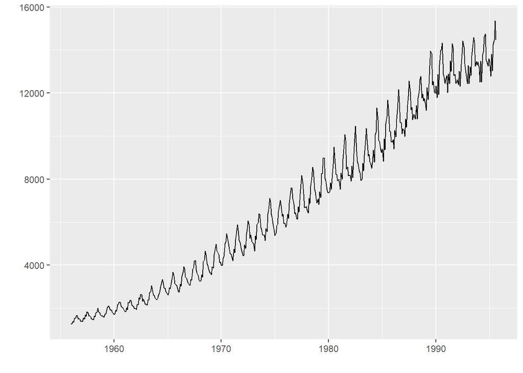

```r
autoplot(ts_122)
```

como bien dijimos antes, notamos que al varianza es creciente, por ende proponemos como primer modelo el resultante de aplicar logaritmo a las observaciones

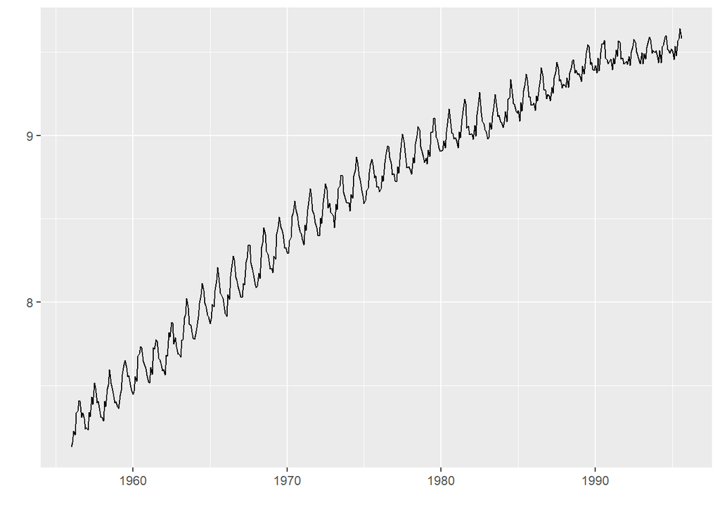

```r
ts_model1 <- log(ts_122)
autoplot(ts_model1)
```

la cual “parece” tener varianza constante. Asimismo, vemos que es necesario que se realice al menos una diferenciación en los datos para quitar la tendencia. Proseguimos realizando el ajuste a un modelo de tipo ARIMA/SARIMA:

```r
fit1 <- auto.arima(ts_model1)
fit1
```

```
## Series: ts_model1
## ARIMA(0,1,1)(2,1,1)[12]
##
## Coefficients:
##           ma1    sar1     sar2     sma1
##       -0.6652  0.0013  -0.1621  -0.6220
## s.e.   0.0392  0.0734   0.0586   0.0627
##
## sigma^2 = 0.0004335:  log likelihood = 1134.19
## AIC=-2258.37   AICc=-2258.24   BIC=-2237.69
```

donde el modelo que obtenemos es un $SARIMA(0,1,1)(2,1,1)_{12}$. Con base en el modelo obtenido anteriormente, con las observaciones de las gráficas y con diversas pruebas hechas buscando mejores modelos, proponemos el siguiente modelo

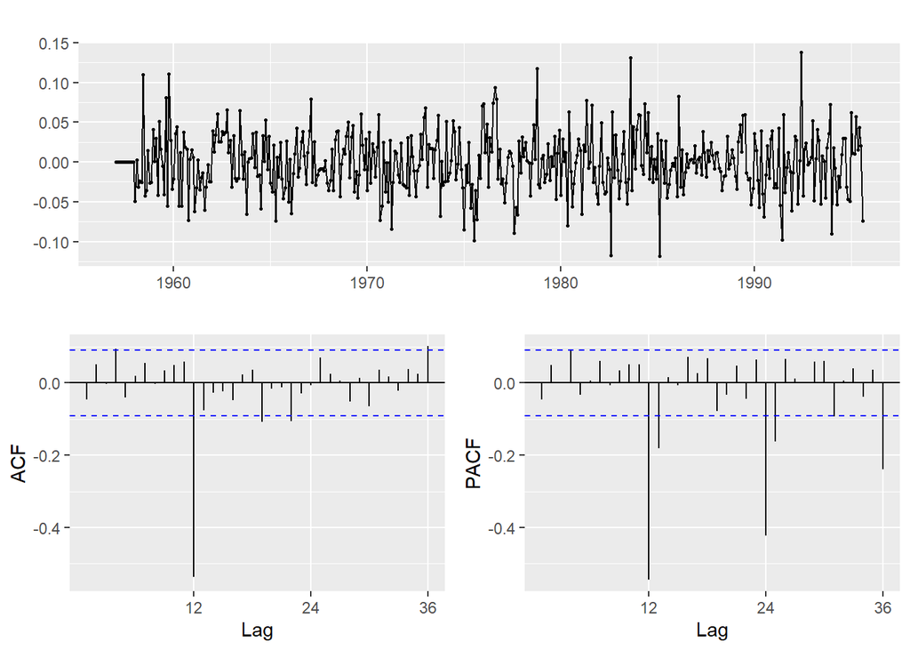

```r
fit11 <- arima(diff(ts_model1,12), c(2, 0, 2), seasonal = list(order = c(0, 1, 0), period = 12))
ggtsdisplay(fit11$residuals)
```

y continuamos realizando el análisis de los supuestos:

**Estacionariedad:**

```r
# Modelo transformado
adf.test(diff(ts_model1,12))
```

```
##
##  Augmented Dickey-Fuller Test
##
## data:  diff(ts_model1, 12)
## Dickey-Fuller = -4.9039, Lag order = 7, p-value = 0.01
## alternative hypothesis: stationary
```

```r
# Datos originales
adf.test(ts_122)
```

```
##
##  Augmented Dickey-Fuller Test
##
## data:  ts_122
## Dickey-Fuller = -3.9981, Lag order = 7, p-value = 0.01
## alternative hypothesis: stationary
```

**Normalidad:**

Comenzamos por ver la qq-plot correspondiente a los residuales:

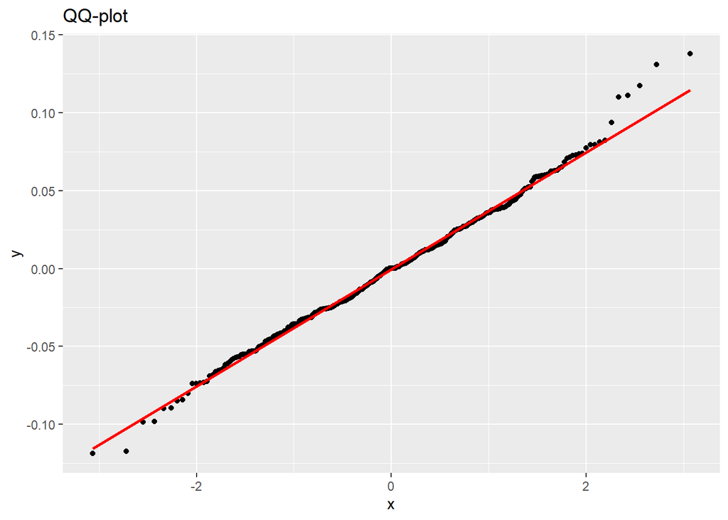

```r
ggplot(fit11, aes(sample=fit11$residuals)) +
  stat_qq() +
  stat_qq_line(col="red", size=1) +
  ggtitle("QQ-plot")
```

donde, al parecer, los residuales siguen una distribución normal. Comprobamos realizando la prueba de *Anderson-Darling*:

```r
ad.test(fit11$residuals)
```

```
##
##  Anderson-Darling normality test
##
## data:  fit11$residuals
## A = 0.49856, p-value = 0.2095
```

de donde no rechazamos $H_{0}$, es decir, es plausible asumir que los residuales siguen una distribución normal.

**Independencia:** Realizamos la prueba de *Box-Pierce* en diversos valores del lag para ver si hay “independencia” entre las observaciones:

```r
Box.test(fit11$residuals)
```

```
##
##  Box-Pierce test
##
## data:  fit11$residuals
## X-squared = 1.0259, df = 1, p-value = 0.3111
```

```r
Box.test(fit11$residuals,lag=1)
```

```
##
##  Box-Pierce test
##
## data:  fit11$residuals
## X-squared = 1.0259, df = 1, p-value = 0.3111
```

```r
Box.test(fit11$residuals,lag=18)
```

```
##
##  Box-Pierce test
##
## data:  fit11$residuals
## X-squared = 151, df = 18, p-value < 2.2e-16
```

```r
Box.test(fit11$residuals,lag=19)
```

```
##
##  Box-Pierce test
##
## data:  fit11$residuals
## X-squared = 156.34, df = 19, p-value < 2.2e-16
```

```r
Box.test(fit11$residuals,lag=12)
```

```
##
##  Box-Pierce test
##
## data:  fit11$residuals
## X-squared = 145.77, df = 12, p-value < 2.2e-16
```

```r
Box.test(fit11$residuals,lag=24)
```

```
##
##  Box-Pierce test
##
## data:  fit11$residuals
## X-squared = 162.25, df = 24, p-value < 2.2e-16
```

vemos que para diversos valores del lag se está rechazando la hipótesis nula, es decir, se está rechazando la “independencia” entre observaciones. Se concluye que este supuesto NO se está cumpliendo.

**Varianza constante:** Para verificar este supuesto realizaremos la prueba de *Breusch_pagan* y la prueba *Non-constant Variance Score Test*:

```r
Y <- as.numeric(fit11$residuals)
X <- 1:length(fit11$residuals)
bptest(Y ~ X)
```

```
##
##  studentized Breusch-Pagan test
##
## data:  Y ~ X
## BP = 1.3654, df = 1, p-value = 0.2426
```

```r
ncvTest(lm(Y~X))
```

```
## Non-constant Variance Score Test
## Variance formula: ~ fitted.values
## Chisquare = 1.784702, Df = 1, p = 0.18157
```

en ambas no se rechaza $H_{0}$, es decir, no se rechaza que la varianza sea constante.

Lo que sigue a continuación es repetir el proceso con otros modelos (especificamente con otros dos modelos):

```r
# Probamos con otras dos transformaciones:
fit2 <- arima(diff(ts_122,12), c(1, 1, 2), seasonal = list(order = c(1 ,1, 1), period = 12))
fit3 <- arima(diff(diff(ts_model1,12)), c(2, 0, 2), seasonal = list(order = c(0, 0, 1), period = 12))
```

**Normalidad:**

```r
ad.test(fit2$residuals)
```

```
##
##  Anderson-Darling normality test
##
## data:  fit2$residuals
## A = 9.6053, p-value < 2.2e-16
```

```r
ad.test(fit3$residuals)
```

```
##
##  Anderson-Darling normality test
##
## data:  fit3$residuals
## A = 0.88778, p-value = 0.02309
```

en ambos modelos se rechaza $H_{0}$, es decir, se rechaza la normalidad.

**Varianza constante:**

```r
# Para el modelo fit2:
Y2 <- as.numeric(fit2$residuals)
X2 <- 1:length(fit2$residuals)
bptest(Y2 ~ X2)
```

```
##
##  studentized Breusch-Pagan test
##
## data:  Y2 ~ X2
## BP = 40.782, df = 1, p-value = 1.702e-10
```

```r
ncvTest(lm(Y2~X2))
```

```
## Non-constant Variance Score Test
## Variance formula: ~ fitted.values
## Chisquare = 174.8841, Df = 1, p = < 2.22e-16
```

```r
# Para el modelo fit3:
Y3 <- as.numeric(fit3$residuals)
X3 <- 1:length(fit3$residuals)
bptest(Y3 ~ X3)
```

```
##
##  studentized Breusch-Pagan test
##
## data:  Y3 ~ X3
## BP = 0.46106, df = 1, p-value = 0.4971
```

```r
ncvTest(lm(Y3~X3))
```

```
## Non-constant Variance Score Test
## Variance formula: ~ fitted.values
## Chisquare = 0.7074545, Df = 1, p = 0.40029
```

para el modelo fit3 no se rechaza $H_{0}$ (no se rechaza que la varianza sea constante); en el modelo fit2 se rechaza $H_{0}$. En este punto podemos ver que, por ahora, el modelo fit3 es mejor al fit2.

**Independencia:**

```r
# Para el modelo fit2:
Box.test(fit2$residuals)
```

```
##
##  Box-Pierce test
##
## data:  fit2$residuals
## X-squared = 0.026198, df = 1, p-value = 0.8714
```

```r
Box.test(fit2$residuals,lag=1)
```

```
##
##  Box-Pierce test
##
## data:  fit2$residuals
## X-squared = 0.026198, df = 1, p-value = 0.8714
```

```r
Box.test(fit2$residuals,lag=18)
```

```
##
##  Box-Pierce test
##
## data:  fit2$residuals
## X-squared = 51.42, df = 18, p-value = 4.592e-05
```

```r
Box.test(fit2$residuals,lag=19)
```

```
##
##  Box-Pierce test
##
## data:  fit2$residuals
## X-squared = 57.388, df = 19, p-value = 9.943e-06
```

```r
Box.test(fit2$residuals,lag=12)
```

```
##
##  Box-Pierce test
##
## data:  fit2$residuals
## X-squared = 27.785, df = 12, p-value = 0.005946
```

```r
Box.test(fit2$residuals,lag=24)
```

```
##
##  Box-Pierce test
##
## data:  fit2$residuals
## X-squared = 101.64, df = 24, p-value = 1.574e-11
```

notamos la presencia de algunas observaciones en las que el *p-value* es menor a 0.05 por lo que se rechaza la hipótesis nula, es decir, se rechaza que los datos sean independientes. Por otro lado

```r
# Para el modelo fit3:
Box.test(fit3$residuals)
```

```
##
##  Box-Pierce test
##
## data:  fit3$residuals
## X-squared = 3.8376e-05, df = 1, p-value = 0.9951
```

```r
Box.test(fit3$residuals,lag=1)
```

```
##
##  Box-Pierce test
##
## data:  fit3$residuals
## X-squared = 3.8376e-05, df = 1, p-value = 0.9951
```

```r
Box.test(fit3$residuals,lag=18)
```

```
##
##  Box-Pierce test
##
## data:  fit3$residuals
## X-squared = 25.119, df = 18, p-value = 0.1217
```

```r
Box.test(fit3$residuals,lag=19)
```

```
##
##  Box-Pierce test
##
## data:  fit3$residuals
## X-squared = 38.497, df = 19, p-value = 0.005127
```

```r
Box.test(fit3$residuals,lag=12)
```

```
##
##  Box-Pierce test
##
## data:  fit3$residuals
## X-squared = 18.006, df = 12, p-value = 0.1155
```

```r
Box.test(fit3$residuals,lag=24)
```

```
##
##  Box-Pierce test
##
## data:  fit3$residuals
## X-squared = 55.296, df = 24, p-value = 0.0002855
```

vemos que en dos observaciones en particular se está rechazando la hipótesis nula, es decir, se rechaza que dichas observaciones sean independientes.